# Age-Specific Patterns of Disease Activity in Patients with Rheumatoid Arthritis

Hajin Jang

Sep 17, 2023

### This document is a basic statistical lab report that uses data from patients with rheumatoid arthritis to conduct an exploratory analysis in R of the distributions of, and relationships among, age, disease activity (DAS_28), and years since diagnosis.

# Load Libraries and Import Data Set

Load libraries

```r
library(tidyverse) # package for plotting/data management
library(readxl) # package for reading in excel files
```

Import the data

```r
# read in data
ra <- read_xlsx("ArthritisTreatment.xlsx")

# Take a look at the data (just top few rows)
head(ra)
```

| ID | Age | AgeGp | Sex | Yrs_From_Dx | CDAI | CDAI_YN | DAS_28 | DAS28_YN | Steroids_GT_5 | DMARDs | Biologics | sDMARDS | OsteopScreen |
| --- | --- | --- | --- | --- | --- | --- | --- | --- | --- | --- | --- | --- | --- |
| 1 | 85 | 2 | 0 | 27 | NA | 1 | NA | 1 | 0 | 1 | 0 | 0 | 0 |
| 2 | 86 | 2 | 0 | 27 | 23.0 | 2 | NA | 1 | 1 | 1 | 0 | 0 | 1 |
| 3 | 83 | 2 | 0 | 10 | 14.5 | 2 | NA | 1 | 1 | 1 | 1 | 0 | 1 |
| 4 | 83 | 2 | 0 | 9 | NA | 1 | NA | 1 | 1 | 1 | 0 | 0 | 1 |
| 5 | 85 | 2 | 0 | NA | NA | 1 | NA | 1 | 0 | 0 | 0 | 0 | 0 |
| 6 | 79 | 2 | 1 | NA | NA | 1 | NA | 1 | 0 | 0 | 0 | 0 | 0 |

```r
# use View(ra) to view the whole data set in a new tab
```

# Part 1: Univariate Descriptions

## Age group

```r
# create new variable with labels
ra <- ra %>%
  mutate( AgeGp_f = factor(AgeGp, levels = c(1,2),
                           labels = c("40-70 years", "75+ years")))

# table of counts
xtabs( ~ AgeGp_f, data = ra) %>% addmargins() # margins show row/column sums
```

```
## AgeGp_f
## 40-70 years   75+ years         Sum
##         459          71         530
```

```r
# table of proportions
xtabs( ~ AgeGp_f, data = ra) %>% prop.table()
```

```
## AgeGp_f
## 40-70 years   75+ years
##   0.8660377   0.1339623
```

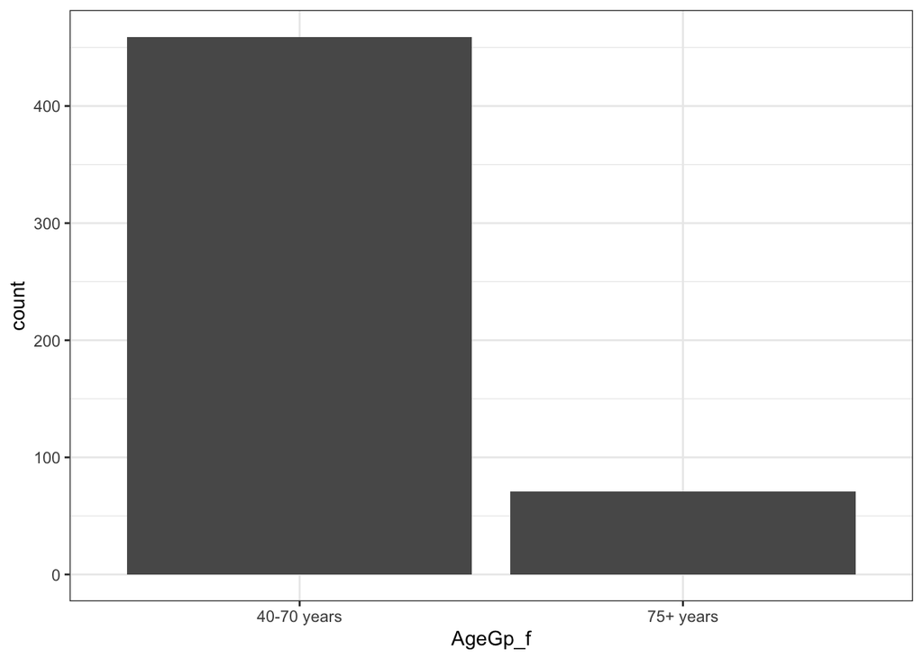

```r
# plot (histogram)
ra %>%
  ggplot(aes(x = AgeGp_f)) + # choose variable to plot
  geom_histogram(stat = "count") + # stat = count indicates that we want to count how many of each category appear in the data and plot those counts
  theme_bw() # background color
```

Description: Age group is a categorical binary variable that divides patients into 2 age groups: 40-70 years and 75+ years. About 86.6% of patients were aged between 40 and 70 years (n=459) and about 13.4% of the patients were aged 75 years or more (n=71).

## Age

```r
# summary statistics
ra %>%
  summarise(mean = mean(Age),
            median = median(Age),
            min = min(Age),
            max = max(Age),
            q25 = quantile(Age, 0.25),
            q75 = quantile(Age,0.75),
            sd = sd(Age)) %>%
mutate(IQR = q75-q25)
```

| mean | median | min | max | q25 | q75 | sd | IQR |
| --- | --- | --- | --- | --- | --- | --- | --- |
| 60.68679 | 59 | 42 | 90 | 54 | 66 | 10.47384 | 12 |

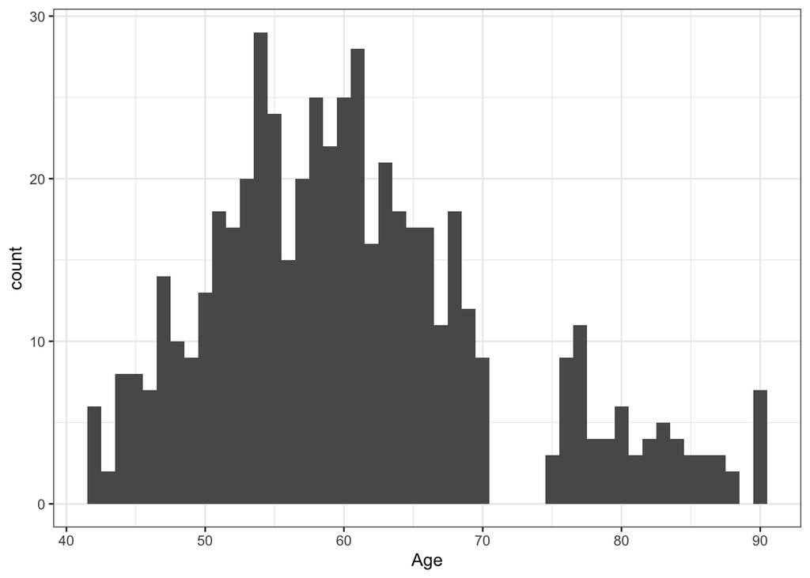

```r
# histogram
ra %>% ggplot(aes(x = Age)) + # plot age
  geom_histogram(binwidth = 1) + # each year gets its own bin, the larger the bin the smoother the histogram
  theme_bw() # background color
```

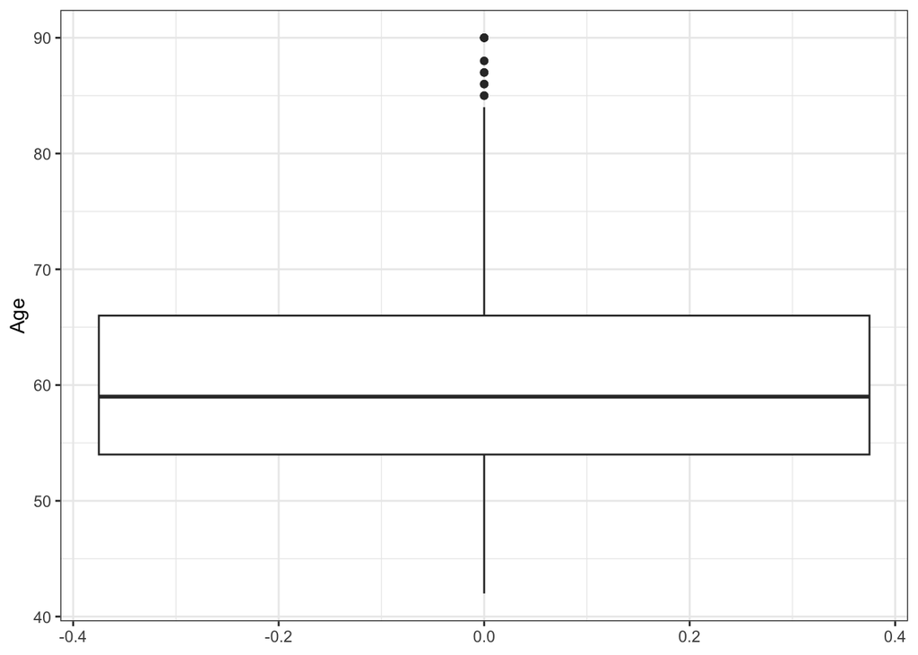

```r
# boxplot
ra %>%
  ggplot(aes(y = Age)) + # change to x = Age for a horizontal boxplot
  geom_boxplot() +
  theme_bw() # background color
```

Description: The mean age of RA patients is 60.7 years with 10.5 years of standard deviation. The median age of them is 59 years, thus the age of RA patients is slightly skewed to the right. The age of RA patients ranges from 42 to 90 years. The interquartile range (IQR) of RA patients stretches from 54 to 66 years showing 12 years of the age difference within IQR.

## Whether DAS_28 was measured

```r
# make a new factor variable with readable labels
ra <- ra %>%
  mutate(DAS28_YN_f = factor(DAS28_YN, levels = c(1,2), labels = c("DAS_28 was not measured","DAS_28 was measured")))

# table of counts
xtabs( ~ DAS28_YN_f, data = ra) %>% addmargins()
```

```
## DAS28_YN_f
## DAS_28 was not measured     DAS_28 was measured                     Sum
##                     464                      66                     530
```

```r
# table of proportions
xtabs( ~ DAS28_YN_f, data = ra) %>% prop.table()
```

```
## DAS28_YN_f
## DAS_28 was not measured     DAS_28 was measured
##               0.8754717               0.1245283
```

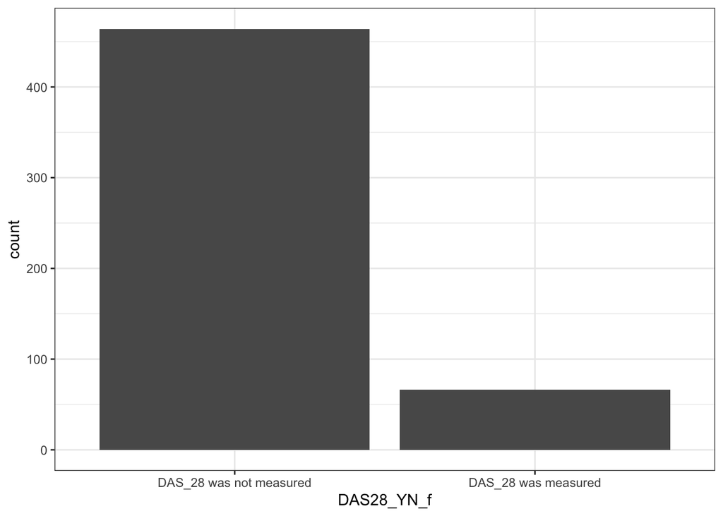

```r
# plot (histogram/bar plot)
ra %>%
  ggplot(aes(x = DAS28_YN_f)) +
  geom_histogram(stat = "count") +
  theme_bw()
```

Description: About 87.5% of RA patients had DAS_28 not measured (n=464) while 12.5% of them (n=66) were measured for DAS_28.

## DAS_28 values

```r
# summary stats
# HINT: use the drop_na() function if you're having trouble
ra %>% drop_na(DAS_28) %>%
 summarise(n=n(),
            mean = mean(DAS_28),
            median = median(DAS_28),
            min = min(DAS_28),
            max = max(DAS_28),
            q25 = quantile(DAS_28, 0.25),
            q75 = quantile(DAS_28,0.75),
            sd = sd(DAS_28)) %>%
mutate(IQR = q75-q25)
```

| n | mean | median | min | max | q25 | q75 | sd | IQR |
| --- | --- | --- | --- | --- | --- | --- | --- | --- |
| 66 | 2.922727 | 2.5 | 0 | 23 | 1.825 | 3.31 | 2.769944 | 1.485 |

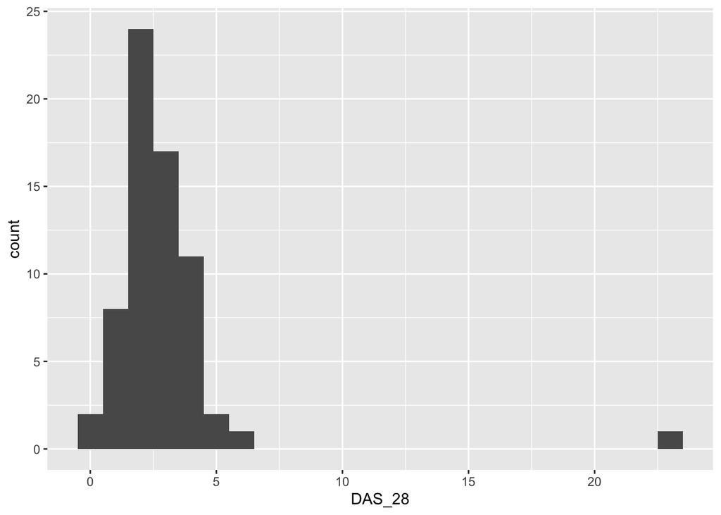

```r
# make some plots
# histogram
ra %>%
  ggplot(aes(x = DAS_28)) + # plot age
  geom_histogram(binwidth = 1) # each year gets its own bin, the larger the bin the smoother the histogram
```

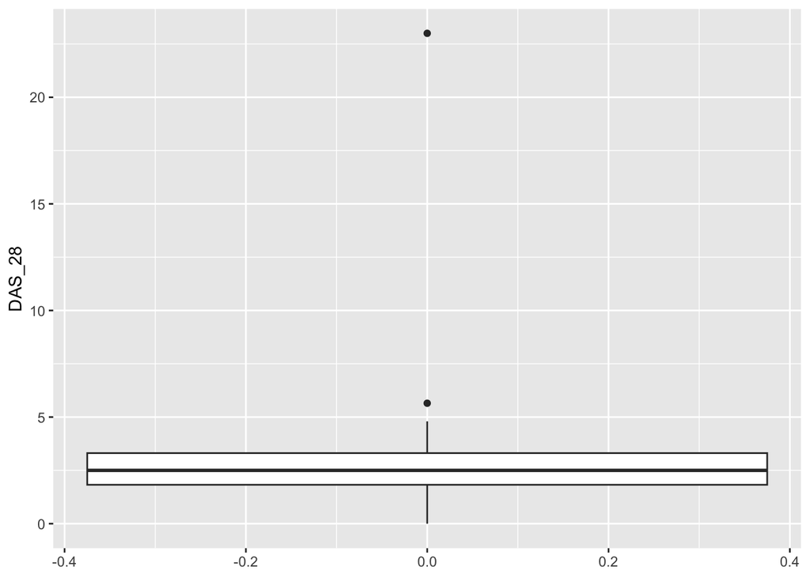

```r
# boxplot
ra %>%
  ggplot(aes(y = DAS_28)) + # change to x = Age for a horizontal boxplot
  geom_boxplot()
```

Description: The value of RA patients’ disease activity score for 28 joints is a continuous variable with a mean value of 2.92 (standard deviation=2.77) and median value of 2.5. Considering the histogram, boxplot, and interquartile range, the maximum value 23 would be the outlier.

## Years since diagnosis of RA

```r
# numerical summary
ra %>% drop_na(Yrs_From_Dx) %>%
  summarise(n=n(),
            mean = mean(Yrs_From_Dx),
            median = median(Yrs_From_Dx),
            min = min(Yrs_From_Dx),
            max = max(Yrs_From_Dx),
            q25 = quantile(Yrs_From_Dx, 0.25),
            q75 = quantile(Yrs_From_Dx,0.75),
            sd = sd(Yrs_From_Dx)) %>%
mutate(IQR = q75-q25)
```

| n | mean | median | min | max | q25 | q75 | sd | IQR |
| --- | --- | --- | --- | --- | --- | --- | --- | --- |
| 515 | 9.4 | 7 | 1 | 70 | 3 | 11 | 9.285108 | 8 |

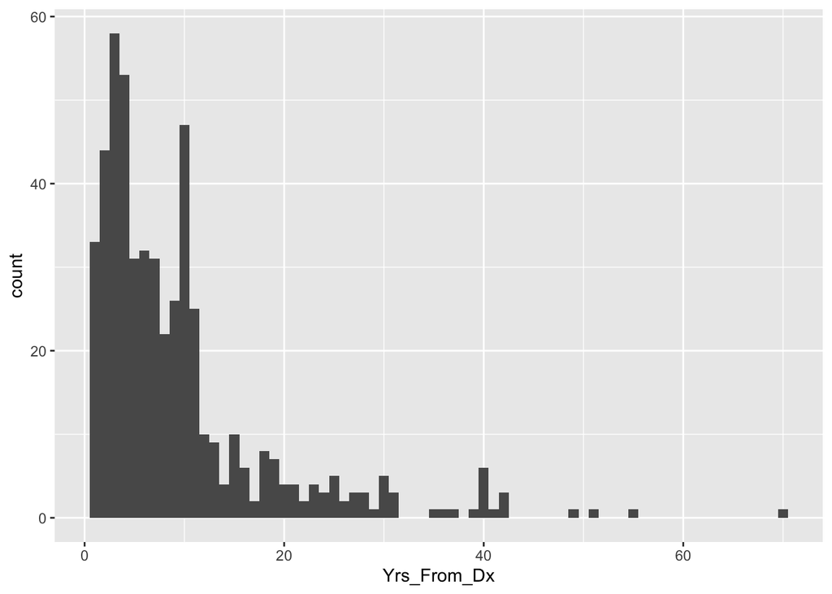

```r
# make some plots
# histogram
ra %>%
  ggplot(aes(x = Yrs_From_Dx)) + # plot age
  geom_histogram(binwidth = 1) # each year gets its own bin, the larger the bin the smoother the histogram
```

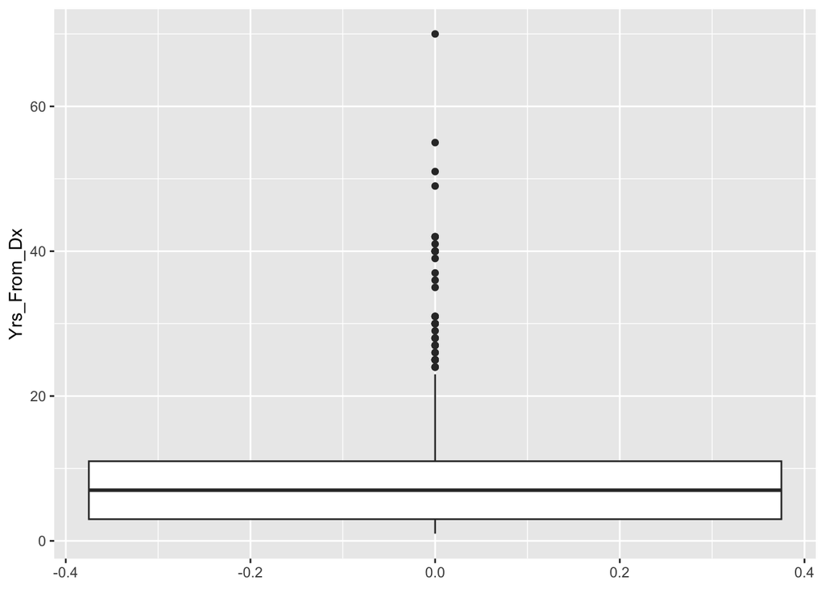

```r
# boxplot
ra %>%
  ggplot(aes(y = Yrs_From_Dx)) + # change to x = Age for a horizontal boxplot
  geom_boxplot()
```

Description: Among 515 RA patients who have value for the variable, the mean years since the diagnosis of RA is 9.4 with fairly high standard deviation reported as 9.29. According to the histogram, the distribution of years since the diagnosis of RA is skewed to right.

# Part 2: Bivariate Descriptions

## Whether DAS_28 was measured and age group

```r
# table with margins
xtabs(~ DAS28_YN_f + AgeGp_f, data = ra) %>%
  addmargins() # print row and column sums
```

```
##                          AgeGp_f
## DAS28_YN_f                40-70 years 75+ years Sum
##   DAS_28 was not measured         397        67 464
##   DAS_28 was measured              62         4  66
##   Sum                             459        71 530
```

```r
# proportion table
xtabs(~ DAS28_YN_f + AgeGp_f, data = ra) %>%
  prop.table(margin = 2) # margin = 1 takes proportion within row; margin = 2 takes proportion within column
```

```
##                          AgeGp_f
## DAS28_YN_f                40-70 years  75+ years
##   DAS_28 was not measured  0.86492375 0.94366197
##   DAS_28 was measured      0.13507625 0.05633803
```

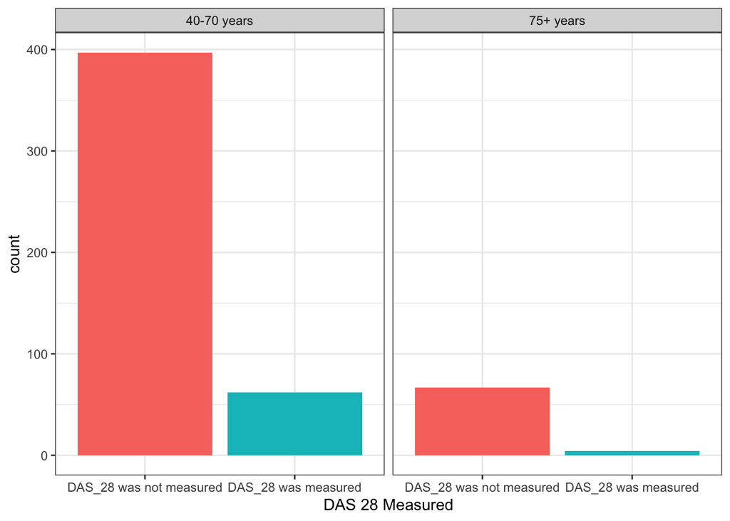

```r
# bar plot with counts
ra %>% ggplot(aes(x = DAS28_YN_f, fill = DAS28_YN_f)) +
  facet_wrap(.~ AgeGp_f) + # separate plot per age group
  geom_histogram(stat = "count") +
  labs(x = "DAS 28 Measured") +
  theme_bw() +
  theme(legend.position = "none") # suppress legend
```

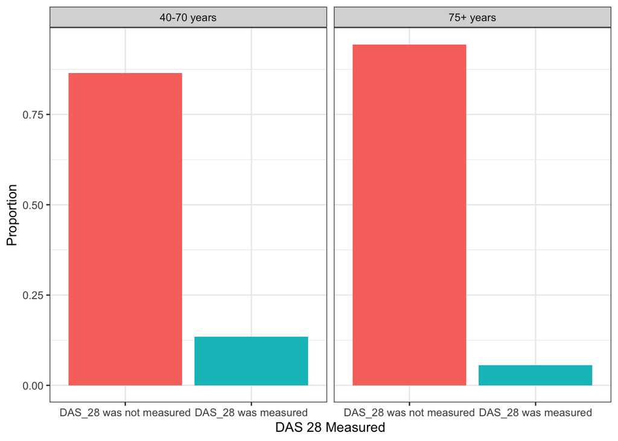

```r
# bar plot with proportion
ra %>%
  group_by(AgeGp_f, DAS28_YN_f) %>%
  tally() %>% # count number in each group
  mutate(prop = n/sum(n)) %>% # take proportion
  ggplot(aes(fill = DAS28_YN_f, x=DAS28_YN_f, y = prop)) +
  geom_histogram(stat = "identity") +
  facet_wrap(.~ AgeGp_f) + # split by age group
  labs(x = "DAS 28 Measured", y = "Proportion") +
  theme_bw() + # background color
  theme(legend.position = "none") # don't print legend
```

Description: Both age groups show that there are more people who have not measured the DAS28 than who have measured. 86.5% of RA patients who aged 40-70 years have not measured DAS28, while 94.4% of RA patients aged 70 or more have not measured DAS28.

## Years since diagnosis of RA and age

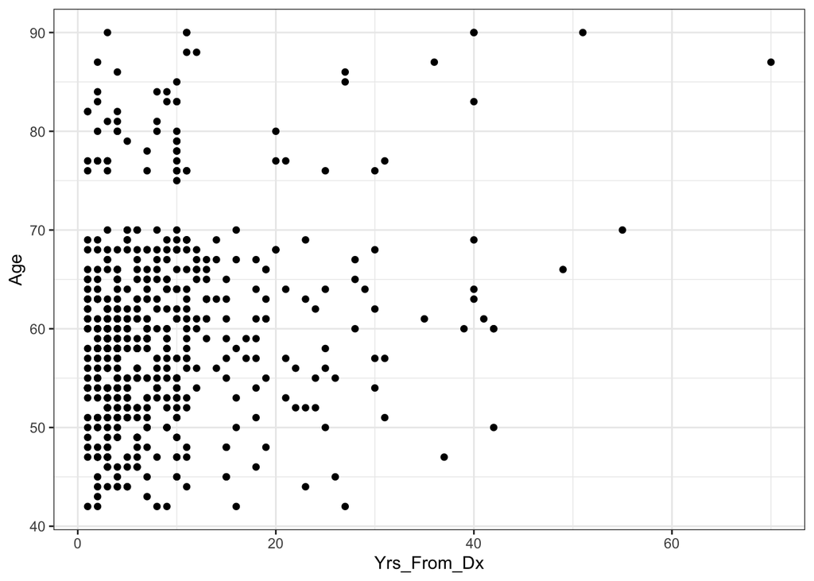

```r
# scatter plot
ra %>% ggplot(aes(x = Yrs_From_Dx, y = Age)) +
  geom_point() +
  theme_bw()
```

```r
# correlation
with(ra, cor(Yrs_From_Dx, Age, use = "pairwise.complete.obs"))
```

```
## [1] 0.1999923
```

Description: The correlation between years since diagnosis of RA and age is 0.20, thus it shows that weak positive correlation exists between the two variables.

## Whether DAS_28 was measured and age

```r
# filter data
ra.f <- ra %>% filter(Sex==0) # only keep rows for which Sex has the value 0
ra.m <- ra %>% filter(Sex==1) # only keep rows for which Sex has the value 1
```

### Female Study Participants

```r
# summary stats
ra.f %>% group_by(DAS28_YN_f) %>%
  summarise(n=n(),
            mean = mean(Age),
            median = median(Age),
            min = min(Age),
            max = max(Age),
            q25 = quantile(Age, 0.25),
            q75 = quantile(Age,0.75),
            sd = sd(Age)) %>%
mutate(IQR = q75-q25)
```

| DAS28_YN_f | n | mean | median | min | max | q25 | q75 | sd | IQR |
| --- | --- | --- | --- | --- | --- | --- | --- | --- | --- |
| DAS_28 was not measured | 373 | 61.12064 | 60 | 42 | 90 | 53 | 67.0 | 11.188701 | 14.0 |
| DAS_28 was measured | 55 | 58.47273 | 58 | 43 | 78 | 53 | 64.5 | 7.920565 | 11.5 |

```r
# table with margins
xtabs(~ DAS28_YN_f + AgeGp_f, data = ra.f) %>%
  addmargins() # print row and column sums
```

```
##                          AgeGp_f
## DAS28_YN_f                40-70 years 75+ years Sum
##   DAS_28 was not measured         314        59 373
##   DAS_28 was measured              52         3  55
##   Sum                             366        62 428
```

```r
# proportion table
xtabs(~ DAS28_YN_f + AgeGp_f, data = ra.f) %>%
  prop.table(margin = 2) # margin = 1 takes proportion within row; margin = 2 takes proportion within column
```

```
##                          AgeGp_f
## DAS28_YN_f                40-70 years 75+ years
##   DAS_28 was not measured   0.8579235 0.9516129
##   DAS_28 was measured       0.1420765 0.0483871
```

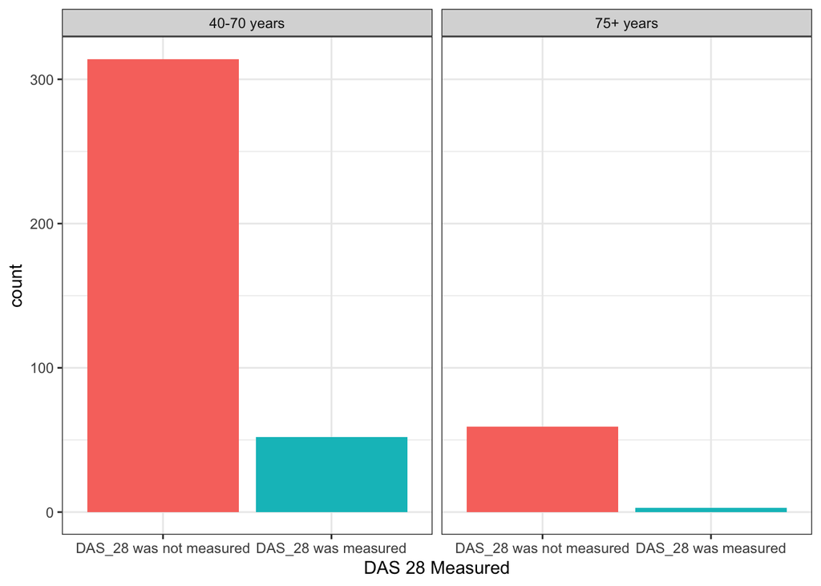

```r
# make some plots
# bar plot with counts
ra.f %>% ggplot(aes(x = DAS28_YN_f, fill = DAS28_YN_f)) +
  facet_wrap(.~ AgeGp_f) + # separate plot per age group
  geom_histogram(stat = "count") +
  labs(x = "DAS 28 Measured") +
  theme_bw() +
  theme(legend.position = "none") # suppress legend
```

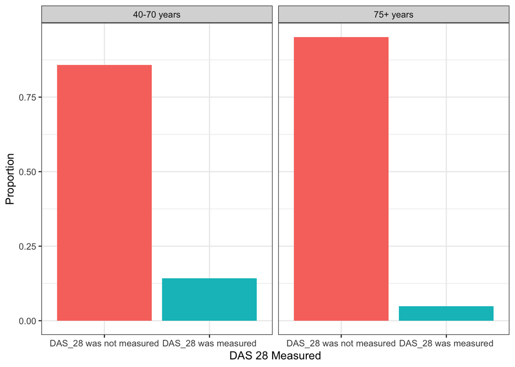

```r
# bar plot with proportion
ra.f %>%
  group_by(AgeGp_f, DAS28_YN_f) %>%
  tally() %>% # count number in each group
  mutate(prop = n/sum(n)) %>% # take proportion
  ggplot(aes(fill = DAS28_YN_f, x=DAS28_YN_f, y = prop)) +
  geom_histogram(stat = "identity") +
  facet_wrap(.~ AgeGp_f) + # split by age group
  labs(x = "DAS 28 Measured", y = "Proportion") +
  theme_bw() + # background color
  theme(legend.position = "none") # don't print legend
```

Description: For both age groups in female RA patients, the proportion of participants who have not measured DAS_28 is higher than those who measured DAS_28 (Age 40-70: 85.8% not measured vs. 14.2% measured; age 70 or above: 95.2% not measured vs. 4.8% measured). This result is similar to the result from overall population. The mean age of female RA patients who have not measured DAS_28 is higher than those who have measured DAS_28 (DAS_28 not measured: 61.1 years; DAS_28 measured: 58.5 years; age difference= 2.6 years).

### Male Study Participants

```r
# summary stats
ra.m %>% group_by(DAS28_YN_f) %>%
  summarise(n=n(),
            mean = mean(Age),
            median = median(Age),
            min = min(Age),
            max = max(Age),
            q25 = quantile(Age, 0.25),
            q75 = quantile(Age,0.75),
            sd = sd(Age)) %>%
mutate(IQR = q75-q25)
```

| DAS28_YN_f | n | mean | median | min | max | q25 | q75 | sd | IQR |
| --- | --- | --- | --- | --- | --- | --- | --- | --- | --- |
| DAS_28 was not measured | 91 | 60.31868 | 59 | 42 | 84 | 54.5 | 65.0 | 8.830351 | 10.5 |
| DAS_28 was measured | 11 | 60.09091 | 59 | 50 | 81 | 56.0 | 60.5 | 8.372031 | 4.5 |

```r
# table with margins
xtabs(~ DAS28_YN_f + AgeGp_f, data = ra.m) %>%
  addmargins() # print row and column sums
```

```
##                          AgeGp_f
## DAS28_YN_f                40-70 years 75+ years Sum
##   DAS_28 was not measured          83         8  91
##   DAS_28 was measured              10         1  11
##   Sum                              93         9 102
```

```r
# proportion table
xtabs(~ DAS28_YN_f + AgeGp_f, data = ra.m) %>%
  prop.table(margin = 2) # margin = 1 takes proportion within row; margin = 2 takes proportion within column
```

```
##                          AgeGp_f
## DAS28_YN_f                40-70 years 75+ years
##   DAS_28 was not measured   0.8924731 0.8888889
##   DAS_28 was measured       0.1075269 0.1111111
```

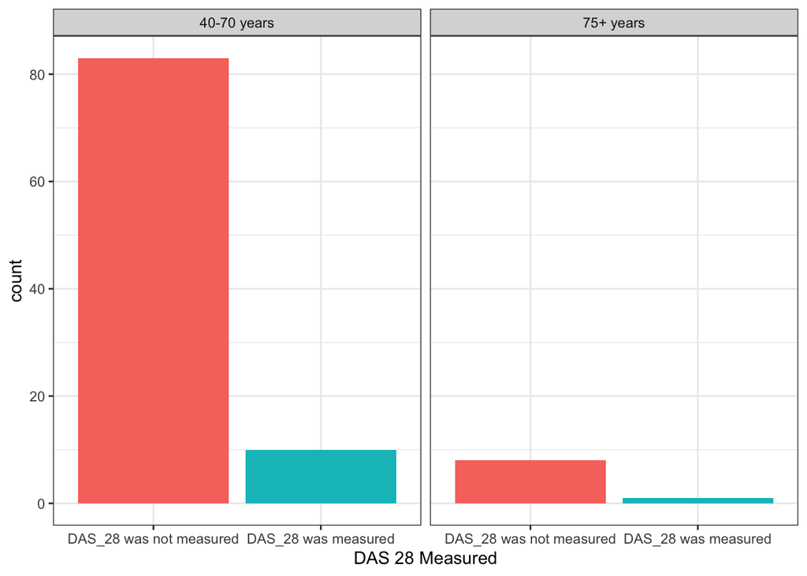

```r
# make some plots
# bar plot with counts
ra.m %>% ggplot(aes(x = DAS28_YN_f, fill = DAS28_YN_f)) +
  facet_wrap(.~ AgeGp_f) + # separate plot per age group
  geom_histogram(stat = "count") +
  labs(x = "DAS 28 Measured") +
  theme_bw() +
  theme(legend.position = "none") # suppress legend
```

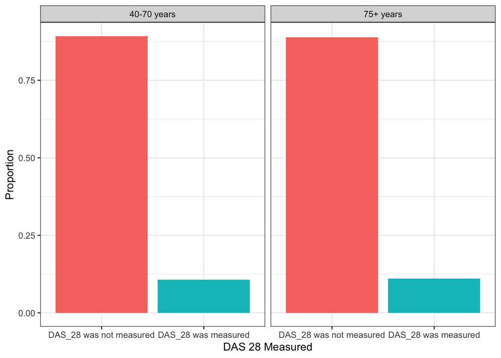

```r
# bar plot with proportion
ra.m %>%
  group_by(AgeGp_f, DAS28_YN_f) %>%
  tally() %>% # count number in each group
  mutate(prop = n/sum(n)) %>% # take proportion
  ggplot(aes(fill = DAS28_YN_f, x=DAS28_YN_f, y = prop)) +
  geom_histogram(stat = "identity") +
  facet_wrap(.~ AgeGp_f) + # split by age group
  labs(x = "DAS 28 Measured", y = "Proportion") +
  theme_bw() + # background color
  theme(legend.position = "none") # don't print legend
```

Description: For both age groups in male RA patients, the proportion of participants who have not measured DAS_28 is higher than those who measured DAS_28 (Age 40-70: 89.2% not measured vs. 10.8% measured; age 70 or above: 88.9% not measured vs. 11.1% measured). This result is similar to the result from overall population and female population as well. The mean age of male RA patients who have not measured DAS_28 is higher than those who have measured DAS_28 (DAS_28 not measured: 60.3 years; DAS_28 measured: 60.1 years; age difference= 0.2 years).

# Summary

The RA patients are more likely to be 40-70 of age (86.6%; mean age=60.7) and female (80.8%; n=428). Most of the RA patients have not measured DAS_28 (87.5%) and this result differed when stratified by age group. When stratified by age group, 86.5% of RA patients aged 40-70 have not measured DAS_28, while 94.4% of RA patients aged 70 or above have not measured DAS_28. Thus, RA patients in the older age group are more likely not to be measured for DAS_28.

The result also differed when further stratified by sex. In female RA patients, those in the older age group were more likely not to be measured for DAS_28 than the younger age group. 85.8% of female patients aged 40-70 and 95.2% of female patients aged 70 or above have not measured DAS_28. However, in male RA patients, those in the younger age group were more likely not to be measured for DAS_28 compared to the older age group. 89.2% of male participants aged 40-70 and 88.9% of male participants aged 70 or above have not measured DAS_28.

According to the results above, it is inappropriate to generalize the trends observed between DAS_28 and the number of years since diagnosis. As DAS_28 shows the severity of RA, it might be positively related to the age of RA patients. However, this does not mean that RA’s severity is also positively related to the number of years since diagnosis. Based on our data, the correlation between age and the number of years since diagnosis was only 0.20. Furthermore, as most of the participants were not measured for DAS_28 (most of the participants were missing DAS_28) and the number of missing observations varied by age and sex (the most important risk factors related to RA), we cannot generalize the results of relationship between severity of RA (DAS_28) and the number of years since diagnosis (Yrs_From_Dx) from our data.